# SeqMonk Vistory Report

## Project Summary

### Basic Project Info

| Parameter | Value |
| --- | --- |
| Project Name | pluripotency_exit_Epi_BS.smk |
| Vistory Name | pluripotency_exit_Epi_BS_210721.smv |
| Genome | Mus musculus GRCm38_v100 |
| SeqMonk Version | 1.48.0 |

### Data Sets

| Name | File Name | Reads | Import Options |
| --- | --- | --- | --- |
| lane1_SLX19733_NEBNext01_TetWT_D0_1_merged_L002_GRCm38_bismark_bt2_pe.deduplicated.bismark.cov.gz | /bi/group/bioinf/Aled_Parry/210630_WGBS_CRUK/COPY_BACK/lane1_SLX19733_NEBNext01_TetWT_D0_1_merged_L002_GRCm38_bismark_bt2_pe.deduplicated.bismark.cov.gz | 296131289 | Cov Parser - No Options |
| lane1_SLX19733_NEBNext02_TetWT_D0_2_merged_L002_GRCm38_bismark_bt2_pe.deduplicated.bismark.cov.gz | /bi/group/bioinf/Aled_Parry/210630_WGBS_CRUK/COPY_BACK/lane1_SLX19733_NEBNext02_TetWT_D0_2_merged_L002_GRCm38_bismark_bt2_pe.deduplicated.bismark.cov.gz | 344843981 | Cov Parser - No Options |
| lane1_SLX19733_NEBNext03_TetWT_D0_3_merged_L002_GRCm38_bismark_bt2_pe.deduplicated.bismark.cov.gz | /bi/group/bioinf/Aled_Parry/210630_WGBS_CRUK/COPY_BACK/lane1_SLX19733_NEBNext03_TetWT_D0_3_merged_L002_GRCm38_bismark_bt2_pe.deduplicated.bismark.cov.gz | 296452369 | Cov Parser - No Options |
| lane1_SLX19733_NEBNext04_TetWT_D1_1_merged_L002_GRCm38_bismark_bt2_pe.deduplicated.bismark.cov.gz | /bi/group/bioinf/Aled_Parry/210630_WGBS_CRUK/COPY_BACK/lane1_SLX19733_NEBNext04_TetWT_D1_1_merged_L002_GRCm38_bismark_bt2_pe.deduplicated.bismark.cov.gz | 312365246 | Cov Parser - No Options |
| lane1_SLX19733_NEBNext05_TetWT_D1_2_merged_L002_GRCm38_bismark_bt2_pe.deduplicated.bismark.cov.gz | /bi/group/bioinf/Aled_Parry/210630_WGBS_CRUK/COPY_BACK/lane1_SLX19733_NEBNext05_TetWT_D1_2_merged_L002_GRCm38_bismark_bt2_pe.deduplicated.bismark.cov.gz | 323738904 | Cov Parser - No Options |
| lane1_SLX19733_NEBNext06_TetWT_D1_3_merged_L002_GRCm38_bismark_bt2_pe.deduplicated.bismark.cov.gz | /bi/group/bioinf/Aled_Parry/210630_WGBS_CRUK/COPY_BACK/lane1_SLX19733_NEBNext06_TetWT_D1_3_merged_L002_GRCm38_bismark_bt2_pe.deduplicated.bismark.cov.gz | 281587095 | Cov Parser - No Options |
| lane1_SLX19733_NEBNext07_TetWT_D2_1_merged_L002_GRCm38_bismark_bt2_pe.deduplicated.bismark.cov.gz | /bi/group/bioinf/Aled_Parry/210630_WGBS_CRUK/COPY_BACK/lane1_SLX19733_NEBNext07_TetWT_D2_1_merged_L002_GRCm38_bismark_bt2_pe.deduplicated.bismark.cov.gz | 329610935 | Cov Parser - No Options |
| lane1_SLX19733_NEBNext08_TetWT_D2_2_merged_L002_GRCm38_bismark_bt2_pe.deduplicated.bismark.cov.gz | /bi/group/bioinf/Aled_Parry/210630_WGBS_CRUK/COPY_BACK/lane1_SLX19733_NEBNext08_TetWT_D2_2_merged_L002_GRCm38_bismark_bt2_pe.deduplicated.bismark.cov.gz | 177422799 | Cov Parser - No Options |
| lane1_SLX19733_NEBNext09_TetWT_D2_3_merged_L002_GRCm38_bismark_bt2_pe.deduplicated.bismark.cov.gz | /bi/group/bioinf/Aled_Parry/210630_WGBS_CRUK/COPY_BACK/lane1_SLX19733_NEBNext09_TetWT_D2_3_merged_L002_GRCm38_bismark_bt2_pe.deduplicated.bismark.cov.gz | 394790507 | Cov Parser - No Options |
| lane1_SLX19733_NEBNext11_TetTKO_D0_1_merged_L001_GRCm38_bismark_bt2_pe.deduplicated.bismark.cov.gz | /bi/group/bioinf/Aled_Parry/210630_WGBS_CRUK/COPY_BACK/lane1_SLX19733_NEBNext11_TetTKO_D0_1_merged_L001_GRCm38_bismark_bt2_pe.deduplicated.bismark.cov.gz | 318623234 | Cov Parser - No Options |
| lane1_SLX19733_NEBNext12_TetTKO_D0_2_merged_L001_GRCm38_bismark_bt2_pe.deduplicated.bismark.cov.gz | /bi/group/bioinf/Aled_Parry/210630_WGBS_CRUK/COPY_BACK/lane1_SLX19733_NEBNext12_TetTKO_D0_2_merged_L001_GRCm38_bismark_bt2_pe.deduplicated.bismark.cov.gz | 341263334 | Cov Parser - No Options |
| lane1_SLX19733_NEBNext19_TetTKO_D0_3_merged_L001_GRCm38_bismark_bt2_pe.deduplicated.bismark.cov.gz | /bi/group/bioinf/Aled_Parry/210630_WGBS_CRUK/COPY_BACK/lane1_SLX19733_NEBNext19_TetTKO_D0_3_merged_L001_GRCm38_bismark_bt2_pe.deduplicated.bismark.cov.gz | 360765937 | Cov Parser - No Options |
| lane1_SLX19733_NEBNext20_TetTKO_D1_1_merged_L001_GRCm38_bismark_bt2_pe.deduplicated.bismark.cov.gz | /bi/group/bioinf/Aled_Parry/210630_WGBS_CRUK/COPY_BACK/lane1_SLX19733_NEBNext20_TetTKO_D1_1_merged_L001_GRCm38_bismark_bt2_pe.deduplicated.bismark.cov.gz | 433064983 | Cov Parser - No Options |
| lane1_SLX19733_NEBNext21_TetTKO_D1_2_merged_L001_GRCm38_bismark_bt2_pe.deduplicated.bismark.cov.gz | /bi/group/bioinf/Aled_Parry/210630_WGBS_CRUK/COPY_BACK/lane1_SLX19733_NEBNext21_TetTKO_D1_2_merged_L001_GRCm38_bismark_bt2_pe.deduplicated.bismark.cov.gz | 313650628 | Cov Parser - No Options |
| lane1_SLX19733_NEBNext22_TetTKO_D1_3_merged_L001_GRCm38_bismark_bt2_pe.deduplicated.bismark.cov.gz | /bi/group/bioinf/Aled_Parry/210630_WGBS_CRUK/COPY_BACK/lane1_SLX19733_NEBNext22_TetTKO_D1_3_merged_L001_GRCm38_bismark_bt2_pe.deduplicated.bismark.cov.gz | 406954539 | Cov Parser - No Options |
| lane1_SLX19733_NEBNext23_TetTKO_D2_1_merged_L001_GRCm38_bismark_bt2_pe.deduplicated.bismark.cov.gz | /bi/group/bioinf/Aled_Parry/210630_WGBS_CRUK/COPY_BACK/lane1_SLX19733_NEBNext23_TetTKO_D2_1_merged_L001_GRCm38_bismark_bt2_pe.deduplicated.bismark.cov.gz | 441381942 | Cov Parser - No Options |
| lane1_SLX19733_NEBNext25_TetTKO_D2_2_merged_L001_GRCm38_bismark_bt2_pe.deduplicated.bismark.cov.gz | /bi/group/bioinf/Aled_Parry/210630_WGBS_CRUK/COPY_BACK/lane1_SLX19733_NEBNext25_TetTKO_D2_2_merged_L001_GRCm38_bismark_bt2_pe.deduplicated.bismark.cov.gz | 288041124 | Cov Parser - No Options |
| lane1_SLX19733_NEBNext26_TetTKO_D2_3_merged_L001_GRCm38_bismark_bt2_pe.deduplicated.bismark.cov.gz | /bi/group/bioinf/Aled_Parry/210630_WGBS_CRUK/COPY_BACK/lane1_SLX19733_NEBNext26_TetTKO_D2_3_merged_L001_GRCm38_bismark_bt2_pe.deduplicated.bismark.cov.gz | 298947981 | Cov Parser - No Options |
| lane1_SLX19733_NEBNext27_DnmtWT_D0_1_merged_L003_GRCm38_bismark_bt2_pe.deduplicated.bismark.cov.gz | /bi/group/bioinf/Aled_Parry/210630_WGBS_CRUK/COPY_BACK/lane1_SLX19733_NEBNext27_DnmtWT_D0_1_merged_L003_GRCm38_bismark_bt2_pe.deduplicated.bismark.cov.gz | 301955931 | Cov Parser - No Options |
| lane1_SLX19733_NEBNext28_DnmtWT_D0_2_merged_L003_GRCm38_bismark_bt2_pe.deduplicated.bismark.cov.gz | /bi/group/bioinf/Aled_Parry/210630_WGBS_CRUK/COPY_BACK/lane1_SLX19733_NEBNext28_DnmtWT_D0_2_merged_L003_GRCm38_bismark_bt2_pe.deduplicated.bismark.cov.gz | 291732391 | Cov Parser - No Options |
| lane1_SLX19733_NEBNext29_DnmtWT_D0_3_merged_L003_GRCm38_bismark_bt2_pe.deduplicated.bismark.cov.gz | /bi/group/bioinf/Aled_Parry/210630_WGBS_CRUK/COPY_BACK/lane1_SLX19733_NEBNext29_DnmtWT_D0_3_merged_L003_GRCm38_bismark_bt2_pe.deduplicated.bismark.cov.gz | 256918728 | Cov Parser - No Options |
| lane1_SLX19733_NEBNext31_DnmtWT_D1_1_merged_L003_GRCm38_bismark_bt2_pe.deduplicated.bismark.cov.gz | /bi/group/bioinf/Aled_Parry/210630_WGBS_CRUK/COPY_BACK/lane1_SLX19733_NEBNext31_DnmtWT_D1_1_merged_L003_GRCm38_bismark_bt2_pe.deduplicated.bismark.cov.gz | 297673058 | Cov Parser - No Options |
| lane1_SLX19733_NEBNext32_DnmtWT_D1_2_merged_L003_GRCm38_bismark_bt2_pe.deduplicated.bismark.cov.gz | /bi/group/bioinf/Aled_Parry/210630_WGBS_CRUK/COPY_BACK/lane1_SLX19733_NEBNext32_DnmtWT_D1_2_merged_L003_GRCm38_bismark_bt2_pe.deduplicated.bismark.cov.gz | 242054680 | Cov Parser - No Options |
| lane1_SLX19733_NEBNext33_DnmtWT_D1_3_merged_L003_GRCm38_bismark_bt2_pe.deduplicated.bismark.cov.gz | /bi/group/bioinf/Aled_Parry/210630_WGBS_CRUK/COPY_BACK/lane1_SLX19733_NEBNext33_DnmtWT_D1_3_merged_L003_GRCm38_bismark_bt2_pe.deduplicated.bismark.cov.gz | 225582382 | Cov Parser - No Options |
| lane1_SLX19733_NEBNext34_DnmtWT_D2_1_merged_L003_GRCm38_bismark_bt2_pe.deduplicated.bismark.cov.gz | /bi/group/bioinf/Aled_Parry/210630_WGBS_CRUK/COPY_BACK/lane1_SLX19733_NEBNext34_DnmtWT_D2_1_merged_L003_GRCm38_bismark_bt2_pe.deduplicated.bismark.cov.gz | 315728192 | Cov Parser - No Options |
| lane1_SLX19733_NEBNext35_DnmtWT_D2_2_merged_L003_GRCm38_bismark_bt2_pe.deduplicated.bismark.cov.gz | /bi/group/bioinf/Aled_Parry/210630_WGBS_CRUK/COPY_BACK/lane1_SLX19733_NEBNext35_DnmtWT_D2_2_merged_L003_GRCm38_bismark_bt2_pe.deduplicated.bismark.cov.gz | 267245845 | Cov Parser - No Options |
| lane1_SLX19733_NEBNext36_DnmtWT_D2_3_merged_L003_GRCm38_bismark_bt2_pe.deduplicated.bismark.cov.gz | /bi/group/bioinf/Aled_Parry/210630_WGBS_CRUK/COPY_BACK/lane1_SLX19733_NEBNext36_DnmtWT_D2_3_merged_L003_GRCm38_bismark_bt2_pe.deduplicated.bismark.cov.gz | 230490989 | Cov Parser - No Options |

### Replicate Sets

| DnmtWT D0 | DnmtWT D1 | DnmtWT D2 | TetTKO D0 | TetTKO D1 | TetTKO D2 | TetWT D0 | TetWT D1 | TetWT D2 |
| --- | --- | --- | --- | --- | --- | --- | --- | --- |
| lane1_SLX19733_NEBNext27_DnmtWT_D0_1_merged_L003_GRCm38_bismark_bt2_pe.deduplicated.bismark.cov.gz | lane1_SLX19733_NEBNext31_DnmtWT_D1_1_merged_L003_GRCm38_bismark_bt2_pe.deduplicated.bismark.cov.gz | lane1_SLX19733_NEBNext34_DnmtWT_D2_1_merged_L003_GRCm38_bismark_bt2_pe.deduplicated.bismark.cov.gz | lane1_SLX19733_NEBNext11_TetTKO_D0_1_merged_L001_GRCm38_bismark_bt2_pe.deduplicated.bismark.cov.gz | lane1_SLX19733_NEBNext20_TetTKO_D1_1_merged_L001_GRCm38_bismark_bt2_pe.deduplicated.bismark.cov.gz | lane1_SLX19733_NEBNext23_TetTKO_D2_1_merged_L001_GRCm38_bismark_bt2_pe.deduplicated.bismark.cov.gz | lane1_SLX19733_NEBNext01_TetWT_D0_1_merged_L002_GRCm38_bismark_bt2_pe.deduplicated.bismark.cov.gz | lane1_SLX19733_NEBNext04_TetWT_D1_1_merged_L002_GRCm38_bismark_bt2_pe.deduplicated.bismark.cov.gz | lane1_SLX19733_NEBNext07_TetWT_D2_1_merged_L002_GRCm38_bismark_bt2_pe.deduplicated.bismark.cov.gz |
| lane1_SLX19733_NEBNext28_DnmtWT_D0_2_merged_L003_GRCm38_bismark_bt2_pe.deduplicated.bismark.cov.gz | lane1_SLX19733_NEBNext32_DnmtWT_D1_2_merged_L003_GRCm38_bismark_bt2_pe.deduplicated.bismark.cov.gz | lane1_SLX19733_NEBNext35_DnmtWT_D2_2_merged_L003_GRCm38_bismark_bt2_pe.deduplicated.bismark.cov.gz | lane1_SLX19733_NEBNext12_TetTKO_D0_2_merged_L001_GRCm38_bismark_bt2_pe.deduplicated.bismark.cov.gz | lane1_SLX19733_NEBNext21_TetTKO_D1_2_merged_L001_GRCm38_bismark_bt2_pe.deduplicated.bismark.cov.gz | lane1_SLX19733_NEBNext25_TetTKO_D2_2_merged_L001_GRCm38_bismark_bt2_pe.deduplicated.bismark.cov.gz | lane1_SLX19733_NEBNext02_TetWT_D0_2_merged_L002_GRCm38_bismark_bt2_pe.deduplicated.bismark.cov.gz | lane1_SLX19733_NEBNext05_TetWT_D1_2_merged_L002_GRCm38_bismark_bt2_pe.deduplicated.bismark.cov.gz | lane1_SLX19733_NEBNext08_TetWT_D2_2_merged_L002_GRCm38_bismark_bt2_pe.deduplicated.bismark.cov.gz |
| lane1_SLX19733_NEBNext29_DnmtWT_D0_3_merged_L003_GRCm38_bismark_bt2_pe.deduplicated.bismark.cov.gz | lane1_SLX19733_NEBNext33_DnmtWT_D1_3_merged_L003_GRCm38_bismark_bt2_pe.deduplicated.bismark.cov.gz | lane1_SLX19733_NEBNext36_DnmtWT_D2_3_merged_L003_GRCm38_bismark_bt2_pe.deduplicated.bismark.cov.gz | lane1_SLX19733_NEBNext19_TetTKO_D0_3_merged_L001_GRCm38_bismark_bt2_pe.deduplicated.bismark.cov.gz | lane1_SLX19733_NEBNext22_TetTKO_D1_3_merged_L001_GRCm38_bismark_bt2_pe.deduplicated.bismark.cov.gz | lane1_SLX19733_NEBNext26_TetTKO_D2_3_merged_L001_GRCm38_bismark_bt2_pe.deduplicated.bismark.cov.gz | lane1_SLX19733_NEBNext03_TetWT_D0_3_merged_L002_GRCm38_bismark_bt2_pe.deduplicated.bismark.cov.gz | lane1_SLX19733_NEBNext06_TetWT_D1_3_merged_L002_GRCm38_bismark_bt2_pe.deduplicated.bismark.cov.gz | lane1_SLX19733_NEBNext09_TetWT_D2_3_merged_L002_GRCm38_bismark_bt2_pe.deduplicated.bismark.cov.gz |

### Quantitation

| Name | Parent | Probes | Description | Comments |
| --- | --- | --- | --- | --- |
| 100 CpG probes |  | 453245 | Read position generation using DnmtWT D0 DnmtWT D1 DnmtWT D2 TetTKO D0 TetTKO D1 TetTKO D2 TetWT D0 TetWT D1 TetWT D2 MinCount=1 Positions per window=100 Ignoring strand. Quantitated with Methylation … |  |

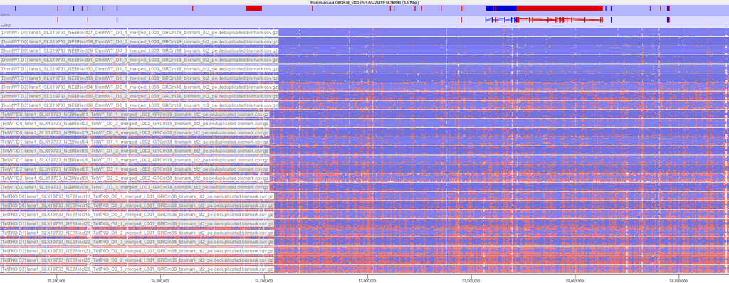

Already from the raw reads one can see the differences in global methylation levels

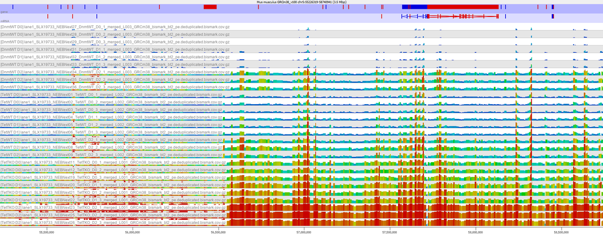

[Even more obvious for quantitation, replicates look similar, seem to match mass spec data well.

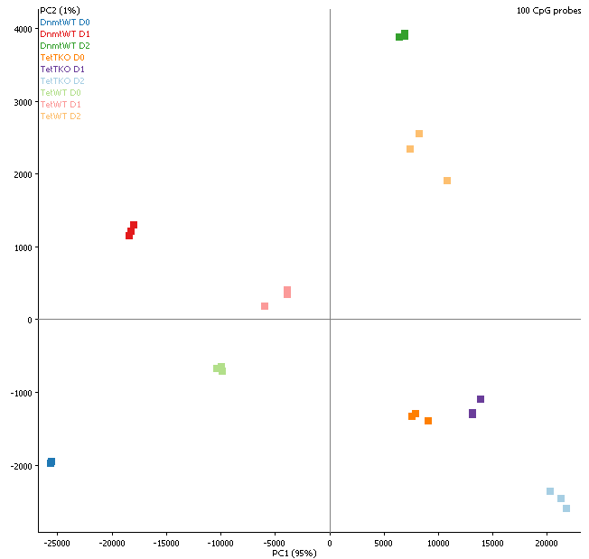

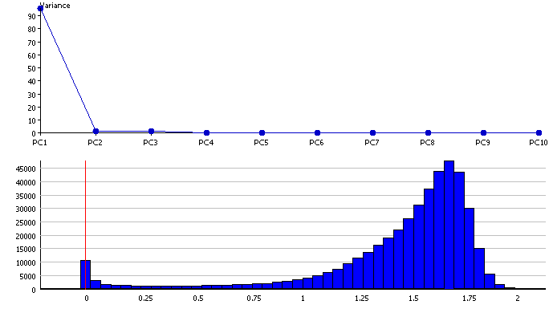

Nice clustering of replicates, most variation is in the global methylation level

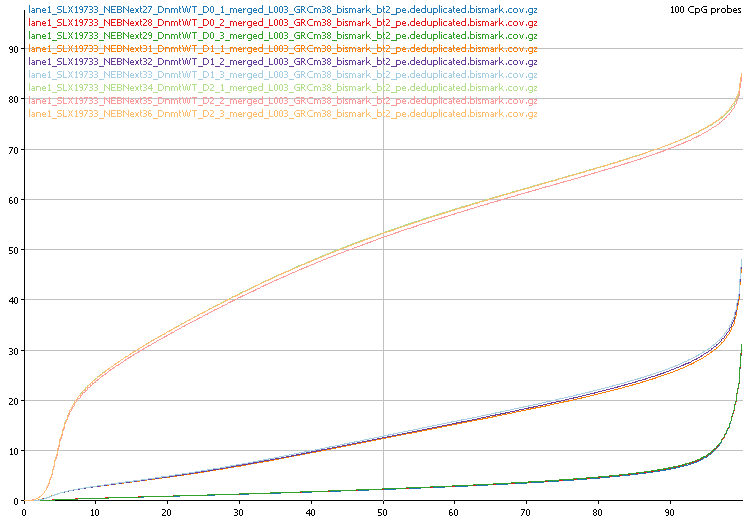

Cumulative distributions very similar between DNMT WT replicates.

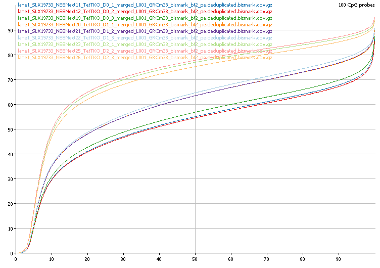

Somewhat less similar for TET KO samples, but still not far off.

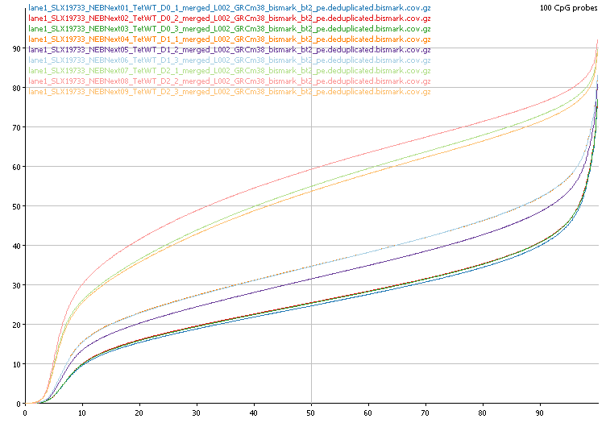

TET WT samples not quite as similar ....

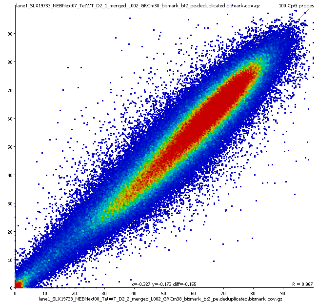

OK, for both TETWT D1 and D2 there is one replicate each which is globally a bit off. I discussed with Felix how to deal with it and we decided not to do anything with it. Even if the methylation is about 5 % off in one replicate, it's not going to make a huge difference overall, especially given the large differences between the time points and conditions. Following the motto 'the fewer corrections the better - if possible'.

The quantitation is currently as follows:

Read position generation using DnmtWT D0 DnmtWT D1 DnmtWT D2 TetTKO D0 TetTKO D1 TetTKO D2 TetWT D0 TetWT D1 TetWT D2 MinCount=1 Positions per window=100 Ignoring strand. Quantitated with Methylation feature pipeline quantitation using [Existing Probes] features with min count of 1 per position, and at least 20 observations per feature, then combining using the Mean

The samples are sequenced really deeply, therefore the min count of 1 could potentially be increase, as could the 20 observations. Then again, there is so much data for each of the samples, that the threshold will not be particularly relevant because essentially all positions are well covered, so weirdness due to coverage is going to be minimal.

Exported mean methylation for 100 CpG windows